# RSM_code

First we’re going to set up R to to our target directory and clear the workspace.

```r
knitr::opts_chunk$set(echo = TRUE,
                      warning = FALSE,
                      message = FALSE,
                      engine = "R", # Chunks will always have R code, unless noted
                      error = TRUE,
                      fig.path="Figures/",  # Set the figure options
                      fig.align = "center",
                      dev='png')
```

Clear RStudio

```r
  # cat(rep("\n",50)) # Clear Console
  rm(list=ls(all=TRUE)) # clear workspace
  graphics.off() # closes all graphics
```

Install function for needed packages

```r
  packages<-function(x){
    x<-as.character(match.call()[[2]])
    if (!require(x,character.only=TRUE)){
      install.packages(pkgs=x,repos="http://cran.r-project.org")
      require(x,character.only=TRUE)
    }
  }
  packages(rsm)
  packages(tidyverse)
  packages(pracma)
  packages(caret)
  packages(e1071)
```

```r
# https://cran.r-project.org/web/packages/rsm/vignettes/rsm.pdf
packages(XLConnect)
data <- readWorksheetFromFile("preliminary_RSM.xlsx",sheet=1)
# Withhold validation points from dataset
data_training <- data[1:13,]
```

Let’s try it with our previous data set:

```r
rsm4 <- rsm(voltage_cycle_4 ~ SO(temp, acetate), data = data_training)
summary(rsm4)
```

```
Call:
rsm(formula = voltage_cycle_4 ~ SO(temp, acetate), data = data_training)

               Estimate Std. Error t value  Pr(>|t|)
(Intercept)   0.0778621  0.0046849 16.6197 6.976e-07 ***
temp          0.0113333  0.0046062  2.4605   0.04344 *
acetate      -0.0021667  0.0046062 -0.4704   0.65238
temp:acetate  0.0022500  0.0056414  0.3988   0.70190
temp^2       -0.0195172  0.0067891 -2.8748   0.02383 *
acetate^2     0.0149828  0.0067891  2.2069   0.06309 .
---
Signif. codes:  0 ‘***’ 0.001 ‘**’ 0.01 ‘*’ 0.05 ‘.’ 0.1 ‘ ’ 1

Multiple R-squared:  0.6976,    Adjusted R-squared:  0.4815
F-statistic: 3.229 on 5 and 7 DF,  p-value: 0.07912

Analysis of Variance Table

Response: voltage_cycle_4
                   Df     Sum Sq    Mean Sq F value  Pr(>F)
FO(temp, acetate)   2 0.00079883 0.00039942  3.1376 0.10646
TWI(temp, acetate)  1 0.00002025 0.00002025  0.1591 0.70190
PQ(temp, acetate)   2 0.00123612 0.00061806  4.8551 0.04758
Residuals           7 0.00089111 0.00012730
Lack of fit         3 0.00045711 0.00015237  1.4043 0.36421
Pure error          4 0.00043400 0.00010850

Stationary point of response surface:
      temp    acetate
0.29324019 0.05028701

Eigenanalysis:
$values
[1]  0.01501940 -0.01955389

$vectors
               [,1]        [,2]
temp    -0.03255683 -0.99946989
acetate -0.99946989  0.03255683
```

Let’s try visualizing these results.

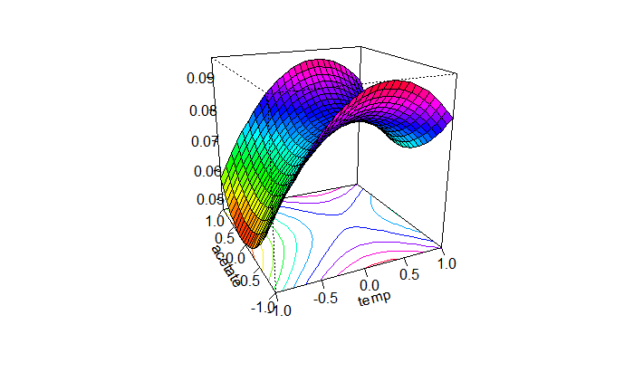

```r
persp(rsm4, ~ temp + acetate, col = rainbow(50), contours = "colors")
```

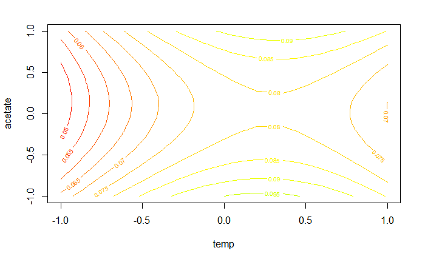

```r
contour(rsm4, ~ temp + acetate, col = rainbow(50), contours = "colors")
```

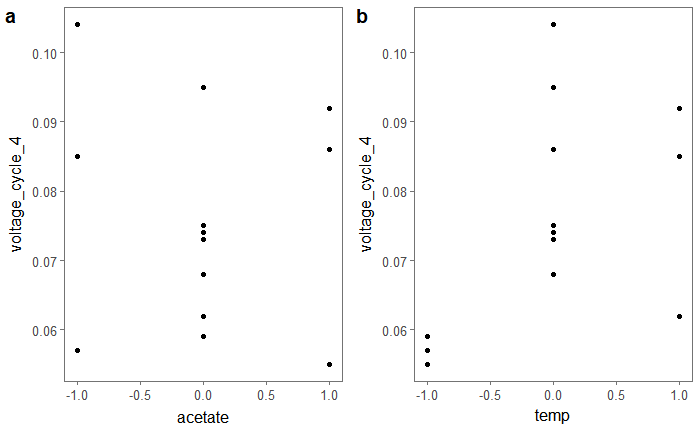

```r
packages(ggplot2)
packages(ggthemes)
packages(cowplot)
plot_acetate <- ggplot(data_training, aes(acetate, voltage_cycle_4)) + geom_point() + theme_few()
plot_temp <- ggplot(data_training, aes(temp, voltage_cycle_4)) + geom_point() + theme_few()
plot_grid(plot_acetate, plot_temp, align='h', labels=c('a', 'b'))
```

Note that we could also plot this with other packages using plot.it=false Now let’s try this with our most recent data set.

```r
rsm5 <- rsm(voltage_cycle_5 ~ SO(temp, acetate), data = data_training)
summary(rsm5)
```

```
Call:
rsm(formula = voltage_cycle_5 ~ SO(temp, acetate), data = data_training)

               Estimate Std. Error t value  Pr(>|t|)
(Intercept)   0.0623448  0.0046122 13.5175 2.849e-06 ***
temp         -0.0021667  0.0045346 -0.4778   0.64735
acetate       0.0020000  0.0045346  0.4410   0.67248
temp:acetate -0.0015000  0.0055538 -0.2701   0.79488
temp^2       -0.0137069  0.0066837 -2.0508   0.07944 .
acetate^2     0.0067931  0.0066837  1.0164   0.34329
---
Signif. codes:  0 ‘***’ 0.001 ‘**’ 0.01 ‘*’ 0.05 ‘.’ 0.1 ‘ ’ 1

Multiple R-squared:  0.4051,    Adjusted R-squared:  -0.01987
F-statistic: 0.9532 on 5 and 7 DF,  p-value: 0.5034

Analysis of Variance Table

Response: voltage_cycle_5
                   Df     Sum Sq    Mean Sq F value Pr(>F)
FO(temp, acetate)   2 0.00005217 2.6083e-05  0.2114 0.8144
TWI(temp, acetate)  1 0.00000900 9.0000e-06  0.0729 0.7949
PQ(temp, acetate)   2 0.00052688 2.6344e-04  2.1352 0.1888
Residuals           7 0.00086364 1.2338e-04
Lack of fit         3 0.00006844 2.2815e-05  0.1148 0.9469
Pure error          4 0.00079520 1.9880e-04

Stationary point of response surface:
       temp     acetate
-0.07055463 -0.15499778

Eigenanalysis:
$values
[1]  0.006820506 -0.013734299

$vectors
               [,1]        [,2]
temp     0.03651217 -0.99933321
acetate -0.99933321 -0.03651217
```

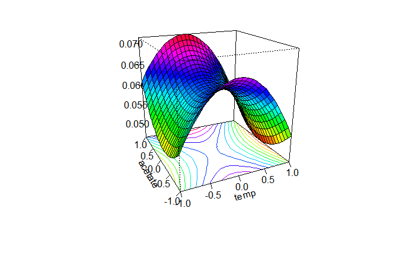

```r
persp(rsm5, ~ temp + acetate, col = rainbow(50), contours = "colors")
```

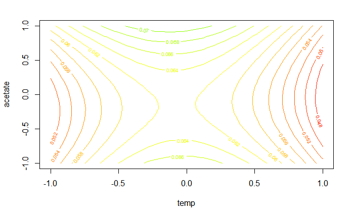

```r
contour(rsm5, ~ temp + acetate, col = rainbow(50), contours = "colors")
```

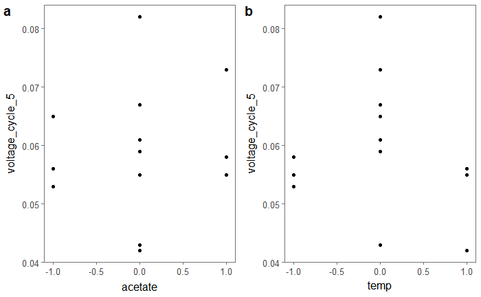

```r
#Look at slices against each factor
plot_acetate <- ggplot(data_training, aes(acetate, voltage_cycle_5)) + geom_point() + theme_few()
plot_temp <- ggplot(data_training, aes(temp, voltage_cycle_5)) + geom_point() + theme_few()
plot_grid(plot_acetate, plot_temp, align='h', labels=c('a', 'b'))
```

Is there a better point in time to analyze this data? Let’s run this against multiple time points and find which creates the best model.

```r
all_p_values <- as.data.frame(matrix(NA,ncol(data_training)-4,7))
packages(broom)
# Start loop
for(i in 5:ncol(data_training)){
model <- rsm(data_training[,i] ~ SO(temp, acetate), data = data_training)
all_p_values[i-4,] <- c(colnames(data_training)[i],as.numeric(tidy(model)$p.value)) # get coefficient table as a data frame https://stackoverflow.com/questions/31570440/extract-regression-p-value-in-r
}
#End Loop
# Append column names
colnames(all_p_values) <- c("Time",tidy(model)$term)
all_p_values
```

| Time | (Intercept) | temp | acetate | temp:acetate | temp^2 | acetate^2 |
| --- | --- | --- | --- | --- | --- | --- |
| voltage_cycle_2 | 0.000453710116475412 | 0.0168105885256002 | 0.62292935761035 | 0.597832028924011 | 0.564068387936172 | 0.426554236860304 |
| voltage_cycle_3 | 1.47356400253834e-06 | 0.000294531196741734 | 0.417064078708081 | 0.487126267894162 | 0.364329832102412 | 0.231111632960895 |
| voltage_cycle_4 | 6.97561846566837e-07 | 0.0434355782052224 | 0.652384758835348 | 0.701899109243504 | 0.0238280987528489 | 0.0630862991751295 |
| voltage_cycle_5 | 2.84897297447242e-06 | 0.647349806499173 | 0.672477963809067 | 0.794883014196255 | 0.0794354902263826 | 0.343285899605044 |

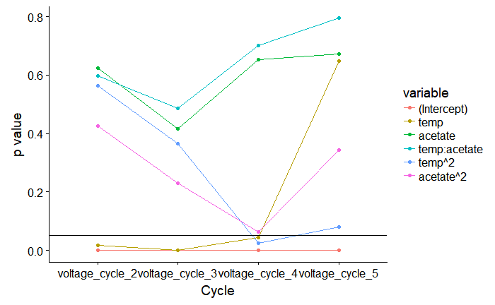

```r
# Turn character into numbers
all_p_values[,2:7] <- as.numeric(unlist(all_p_values[,2:7]))
#Reshape
packages(reshape2)
all_p_values <- melt(all_p_values)
# Plot
ggplot(data=all_p_values, aes(Time,value, group=variable)) +
  geom_line(aes(color=variable))+
  geom_point(aes(color=variable))+
  xlab("Cycle")+
  ylab("p value")+
  geom_hline(yintercept = .05)
```

```r
  # +   scale_x_date(format = "%b-%Y") + xlab("") + ylab("Daily Views")
```

Now let’s load in all the cycle 5 data so far.

```r
# import data
cycle_5_data <- as.data.frame(read.csv("cycle_5_data.csv"))
# get into correct form
# remove first two columns
cycle_5_data <- cycle_5_data[,-c(1:2)]
#transpose
# first remember the names
n <- cycle_5_data[,1]
cycle_5_data <- as.data.frame(t(cycle_5_data[,-1]))
colnames(cycle_5_data) <- n
cycle_5_data$myfactor <- factor(row.names(cycle_5_data))
#knit to past data
cycle_5_rsm <- cbind(data[,c(1:4)],cycle_5_data)
#Take out rows 14 and 15
cycle_5_rsm <- cycle_5_rsm[-c(14:15),]
# last col seems to contain row names. take out
cycle_5_rsm <- cycle_5_rsm[,-922]
# Previous code
# Create blank matrix to fill in with p values
all_p_values <- as.data.frame(matrix(NA,ncol(cycle_5_rsm)-4,7))
packages(broom)
# Start loop
for(i in 5:ncol(cycle_5_rsm)){
model <- rsm(cycle_5_rsm[,i] ~ SO(temp, acetate), data = cycle_5_rsm)
all_p_values[i-4,] <- c(colnames(cycle_5_rsm)[i],as.numeric(tidy(model)$p.value)) # get coefficient table as a data frame https://stackoverflow.com/questions/31570440/extract-regression-p-value-in-r
}
#End Loop
# Append column names
colnames(all_p_values) <- c("Time",tidy(model)$term)
all_p_values
```

| Time | (Intercept) | temp | acetate | temp:acetate | temp^2 | acetate^2 |
| --- | --- | --- | --- | --- | --- | --- |
| 42989.65 | 0.00383975479678672 | 0.0923561621693861 | 0.573424566200973 | 0.32919594774314 | 0.141330650220945 | 0.628653138207949 |
| 42989.66 | 0.000684466639509097 | 0.867587197632837 | 0.333926818450475 | 0.636268329986816 | 0.164194347339184 | 0.633960489554008 |
| 42989.68 | 0.00029306497183563 | 0.682780335306408 | 0.353149748810384 | 0.550959773849031 | 0.141468110686959 | 0.711766601402619 |
| 42989.69 | 0.000142359381130551 | 0.514299027161683 | 0.419027922082908 | 0.446686231417722 | 0.176694808114831 | 0.831445120043509 |
| 42989.7 | 7.78767883244948e-05 | 0.513001607121335 | 0.43258157264627 | 0.426642758633897 | 0.25732057671755 | 0.905631357925109 |
| 42989.72 | 5.18733051766356e-05 | 0.499946633837001 | 0.392890987023602 | 0.468407214934948 | 0.391840370554871 | 0.966188200883534 |
| 42989.73 | 3.37638971450284e-05 | 0.510592140318545 | 0.358876064252647 | 0.523133787696437 | 0.549731885212817 | 0.96879672629557 |
| 42989.74 | 2.77121931759729e-05 | 0.542865733377774 | 0.305869238026061 | 0.633480170416375 | 0.669930819062384 | 0.930988466289628 |
| 42989.76 | 1.79932439414551e-05 | 0.548191841890677 | 0.279715158315485 | 0.697784081369667 | 0.837441104161059 | 0.930303743402384 |
| 42989.77 | 1.58884873344271e-05 | 0.58690157920703 | 0.248521480798336 | 0.831991428989908 | 0.962768606654459 | 0.915978539703017 |

[output cut: 907 more lines]

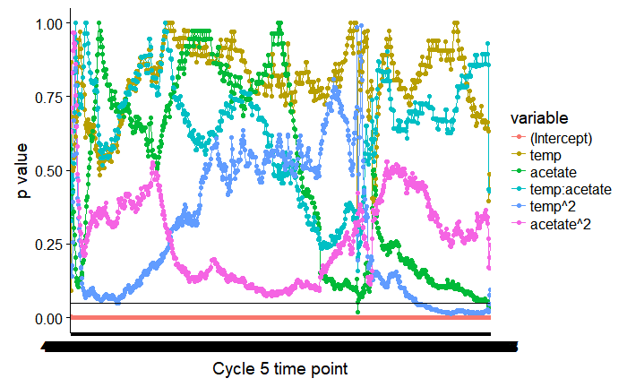

```r
# Turn character into numbers
all_p_values[,2:7] <- as.numeric(unlist(all_p_values[,2:7]))
#Reshape
packages(reshape2)
all_p_values <- melt(all_p_values)
# Plot
ggplot(data=all_p_values, aes(Time,value, group=variable)) +
  geom_line(aes(color=variable))+
  geom_point(aes(color=variable))+
  xlab("Cycle 5 time point")+
  ylab("p value")+
  geom_hline(yintercept = .05)
```

Wow let’s zoom in on that recent time period where a couple of terms become significant.

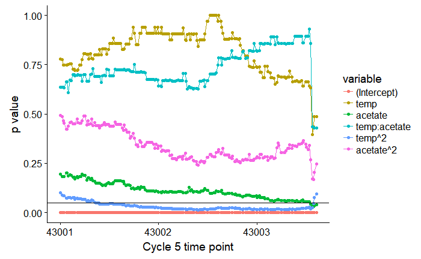

```r
all_p_values$Time <- as.numeric(all_p_values$Time)
ggplot(data=all_p_values, aes(Time,value, group=variable)) +
  geom_line(aes(color=variable))+
  geom_point(aes(color=variable))+
  xlab("Cycle 5 time point")+
  ylab("p value")+
  geom_hline(yintercept = .05)+
  xlim(43001,NA)
```

Wow now let’s zoom in even more.

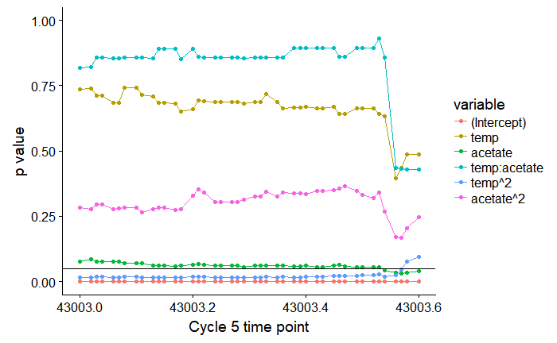

```r
all_p_values$Time <- as.numeric(all_p_values$Time)
ggplot(data=all_p_values, aes(Time,value, group=variable)) +
  geom_line(aes(color=variable))+
  geom_point(aes(color=variable))+
  xlab("Cycle 5 time point")+
  ylab("p value")+
  geom_hline(yintercept = .05)+
  xlim(43003,NA)
```

What happens if we do an RSM with the most recent data?

```r
rsm5 <- rsm(cycle_5_rsm[,ncol(cycle_5_rsm)-3]~SO(temp,acetate), data = cycle_5_rsm)
cycle_5_significant <- cycle_5_data[,"43003.56"]
summary(rsm5)
```

```
Call:
rsm(formula = cycle_5_rsm[, ncol(cycle_5_rsm) - 3] ~ SO(temp,
    acetate), data = cycle_5_rsm)

               Estimate Std. Error t value  Pr(>|t|)
(Intercept)   0.0452069  0.0037567 12.0338 6.239e-06 ***
temp         -0.0033333  0.0036935 -0.9025   0.39679
acetate       0.0096667  0.0036935  2.6172   0.03455 *
temp:acetate -0.0037500  0.0045236 -0.8290   0.43447
temp^2       -0.0157241  0.0054439 -2.8884   0.02337 *
acetate^2     0.0082759  0.0054439  1.5202   0.17226
---
Signif. codes:  0 ‘***’ 0.001 ‘**’ 0.01 ‘*’ 0.05 ‘.’ 0.1 ‘ ’ 1

Multiple R-squared:  0.7071,    Adjusted R-squared:  0.4979
F-statistic:  3.38 on 5 and 7 DF,  p-value: 0.07172

Analysis of Variance Table

Response: cycle_5_rsm[, ncol(cycle_5_rsm) - 3]
                   Df     Sum Sq    Mean Sq F value  Pr(>F)
FO(temp, acetate)   2 0.00062733 0.00031367  3.8321 0.07515
TWI(temp, acetate)  1 0.00005625 0.00005625  0.6872 0.43447
PQ(temp, acetate)   2 0.00069976 0.00034988  4.2745 0.06122
Residuals           7 0.00057297 0.00008185
Lack of fit         3 0.00047777 0.00015926  6.6914 0.04880
Pure error          4 0.00009520 0.00002380

Stationary point of response surface:
       temp     acetate
-0.03539641 -0.59204728

Eigenanalysis:
$values
[1]  0.008421463 -0.015869739

$vectors
               [,1]        [,2]
temp     0.07742082 -0.99699850
acetate -0.99699850 -0.07742082
```

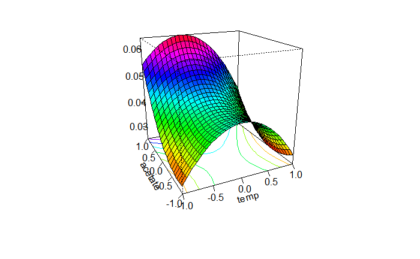

```r
persp(rsm5, ~ temp + acetate, col = rainbow(50), contours = "colors")
```

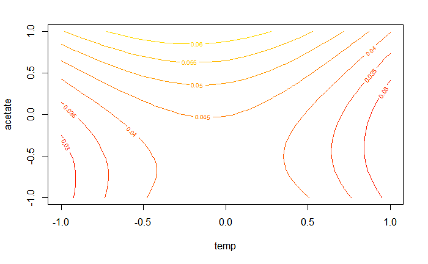

```r
contour(rsm5, ~ temp + acetate, col = rainbow(50), contours = "colors")
```

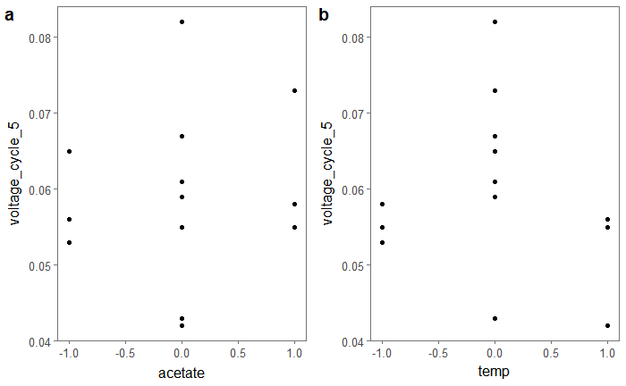

```r
#Look at slices against each factor
plot_acetate <- ggplot(data_training, aes(acetate, voltage_cycle_5)) + geom_point() + theme_few()
plot_temp <- ggplot(data_training, aes(temp, voltage_cycle_5)) + geom_point() + theme_few()
plot_grid(plot_acetate, plot_temp, align='h', labels=c('a', 'b'))
```

Great let’s transform the voltage data to power data given that the external voltage was constant at 1000 ohms.

```r
#Power in Watts
resistance <- 1000
myData <- cycle_5_rsm
myData[,5:ncol(myData)] <- myData[,5:ncol(myData)]^2/resistance #voltage squared divided by resistance
# RSM
rsm5 <- rsm(myData[,ncol(myData)-3] ~ SO(temp, acetate), data = myData)
# summary(rsm5) # throws an error here
# persp(rsm5, ~ temp + acetate, col = rainbow(50), contours = "colors")
# contour(rsm5, ~ temp + acetate, col = rainbow(50), contours = "colors")
#
# #Look at slices against each factor
# plot_acetate <- ggplot(data_training, aes(acetate, voltage_cycle_5)) + geom_point() + theme_few()
# plot_temp <- ggplot(data_training, aes(temp, voltage_cycle_5)) + geom_point() + theme_few()
# plot_grid(plot_acetate, plot_temp, align='h', labels=c('a', 'b'))
```

Let’s see if we can import our COD data. Did COD reduction differ significantly between units or across cycles?

```r
#Import
packages(readr)
cod <- read_csv("cod_results.csv",col_types = cols(MFC = "c"))
cod
```

| MFC | 1 | 2 | 3 | 4 | 5 |
| --- | --- | --- | --- | --- | --- |
| 1 | 365 | 331.5000 | 351 | 407.0000 | 238.0 |
| 2 | 313 | 312.0000 | 351 | 344.0000 | 215.0 |
| 3 | 302 | 352.0000 | 293 | 252.0000 | 173.0 |
| 4 | 270 | 265.8333 | 358 | 313.0000 | 249.0 |
| 5 | 293 | 298.0000 | 264 | 362.0000 | 263.0 |
| 6 | 313 | 359.0000 | 361 | 385.0000 | 203.0 |
| 7 | 292 | 297.0000 | 259 | 289.0000 | 206.0 |
| 8 | 286 | 330.0000 | 351 | 257.0000 | 191.0 |
| 9 | 297 | 337.0000 | 344 | 198.3667 | 221.0 |
| 10 | 340 | 310.6667 | 342 | 219.2000 | 203.0 |

[output cut: 5 more lines]

```r
#get in long format. Columns: mfcNumber, cycleNumber, endCOD, CODReductionPercent
cod <- melt(cod)
names(cod)[names(cod) == 'variable'] <- 'cycle'
names(cod)[names(cod) == 'MFC'] <- 'mfc'
names(cod)[names(cod) == 'value'] <- 'cod_mg_L'
cod$cod_mg_L <- cod$cod_mg_L*100
head(cod)
```

|  | mfc | cycle | cod_mg_L |
| --- | --- | --- | --- |
| 1 | 1 | 1 | 36500 |
| 2 | 2 | 1 | 31300 |
| 3 | 3 | 1 | 30200 |
| 4 | 4 | 1 | 27000 |
| 5 | 5 | 1 | 29300 |
| 6 | 6 | 1 | 31300 |

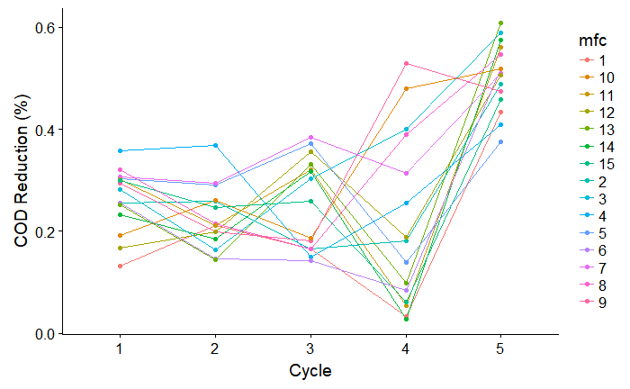

```r
initial_cod <- 42067
cod$delta_cod_mg_L <- initial_cod-cod$cod_mg_L
cod$reduction_percent <- cod$delta_cod_mg_L/initial_cod
# plot
ggplot(data=cod, aes(x = cycle,reduction_percent, group=mfc)) +
  geom_line(aes(color=mfc))+
  geom_point(aes(color=mfc))+
  xlab("Cycle")+
  ylab("COD Reduction (%)")
```

```r
# run analysis
write_csv(cod,"cod_output_from_R.csv")
cod$cycle <- as.numeric(cod$cycle)
model <- lm(reduction_percent~mfc*cycle,data = cod)
anova(model)
```

```
Analysis of Variance Table

Response: reduction_percent
          Df  Sum Sq Mean Sq F value    Pr(>F)
mfc       14 0.13903 0.00993  0.4620 0.9414815
cycle      1 0.33361 0.33361 15.5198 0.0002814 ***
mfc:cycle 14 0.10561 0.00754  0.3509 0.9818058
Residuals 45 0.96732 0.02150
---
Signif. codes:  0 ‘***’ 0.001 ‘**’ 0.01 ‘*’ 0.05 ‘.’ 0.1 ‘ ’ 1
```

```r
cod$cycle <- as.factor(cod$cycle)
#
# Fit a model using the lm function and look at the parameter estimates and standard errors for the treatment effects
  # https://www.r-bloggers.com/one-way-analysis-of-variance-anova/
  model = lm(reduction_percent ~ cycle, data = cod)
  # We save the model fitted to the data in an object so that we can undertake various actions to study the goodness of the fit to the data and other model assumptions.
  # summary(model)
  # An analysis of variance table for this model can be produced via the anova command
  anova.model = anova(model)
  anova.model
```

```
Analysis of Variance Table

Response: reduction_percent
          Df  Sum Sq  Mean Sq F value    Pr(>F)
cycle      4 0.86364 0.215911  22.163 7.511e-12 ***
Residuals 70 0.68193 0.009742
---
Signif. codes:  0 ‘***’ 0.001 ‘**’ 0.01 ‘*’ 0.05 ‘.’ 0.1 ‘ ’ 1
```

```r
# Alternative method (http://personality-project.org/r/r.guide/r.anova.html)
  aov_model = aov(reduction_percent ~ cycle, data = cod)  #do the analysis of variance
  cat("\n")
```

```r
  summary(aov_model)                                    #show the summary table
```

```
            Df Sum Sq Mean Sq F value   Pr(>F)
cycle        4 0.8636 0.21591   22.16 7.51e-12 ***
Residuals   70 0.6819 0.00974
---
Signif. codes:  0 ‘***’ 0.001 ‘**’ 0.01 ‘*’ 0.05 ‘.’ 0.1 ‘ ’ 1
```

```r
  cat("\n")
```

```r
  print(model.tables(aov_model,"means"),digits=3)       #report the means and the number of subjects/cell
```

```
Tables of means
Grand mean

0.2926723

 cycle
cycle
    1     2     3     4     5
0.263 0.226 0.253 0.216 0.504
```

```r
# Interpret the Omnibus ANOVA Test Results
  pvaluecolumn <- anova.model$"Pr(>F)" # Extracts p RA_cluster_in_label column
  pvalue = pvaluecolumn[1] # Extracts first row from p RA_cluster_in_label column
  cat("\n")
```

```r
  cat("ANOVA p value is",pvalue,"\n") # Displays p value
```

```
ANOVA p value is 7.511176e-12
```

```r
  if (pvalue>.05) {
    writeLines("Results are not significant. Fail to reject null hypothesis.")
  } else {
    writeLines("Results are significant. Reject null hypothesis.")
  }
```

```
Results are significant. Reject null hypothesis.
```

```r
# Run Post-Hoc Tukey HSD between treatment groups
  cat("\n")
```

```r
TukeyHSD(aov_model)
```

```
  Tukey multiple comparisons of means
    95% family-wise confidence level

Fit: aov(formula = reduction_percent ~ cycle, data = cod)

$cycle
            diff        lwr        upr     p adj
2-1 -0.037083700 -0.1380023 0.06383493 0.8411282
3-1 -0.009984073 -0.1109027 0.09093456 0.9986784
4-1 -0.047633009 -0.1485516 0.05328562 0.6787763
5-1  0.241075744  0.1401571 0.34199437 0.0000000
3-2  0.027099627 -0.0738190 0.12801826 0.9432298
4-2 -0.010549309 -0.1114679 0.09036932 0.9983599
5-2  0.278159444  0.1772408 0.37907807 0.0000000
4-3 -0.037648936 -0.1385676 0.06326969 0.8336480
5-3  0.251059817  0.1501412 0.35197845 0.0000000
5-4  0.288708753  0.1877901 0.38962738 0.0000000
```

Does Cycle 5 COD reduction percent fit to our response surface? It doesn’t seem to.

```r
# get cycle 5 cod data
rsm_cols <- data[,-c(5:ncol(data))]
rsm_cols$type <- gsub("valdiation","validation",rsm_cols$type)
cycle_5_rsm <- cbind(rsm_cols,cod$reduction_percent[cod$cycle %in% 5])
colnames(cycle_5_rsm)[5] <- "cod_reduction_percent"
#Build model
cycle_5_rsm_training <- cycle_5_rsm[-c(14:15),]
rsmModel <- rsm(cod_reduction_percent ~ SO(temp, acetate), data = cycle_5_rsm_training)
summary(rsmModel)
```

```
Call:
rsm(formula = cod_reduction_percent ~ SO(temp, acetate), data = cycle_5_rsm_training)

               Estimate Std. Error t value  Pr(>|t|)
(Intercept)   0.5277648  0.0247799 21.2981 1.267e-07 ***
temp          0.0170363  0.0243634  0.6993   0.50695
acetate       0.0015848  0.0243634  0.0650   0.94996
temp:acetate -0.0588347  0.0298390 -1.9717   0.08926 .
temp^2        0.0173369  0.0359095  0.4828   0.64398
acetate^2    -0.0718066  0.0359095 -1.9997   0.08566 .
---
Signif. codes:  0 ‘***’ 0.001 ‘**’ 0.01 ‘*’ 0.05 ‘.’ 0.1 ‘ ’ 1

Multiple R-squared:  0.5475,    Adjusted R-squared:  0.2243
F-statistic: 1.694 on 5 and 7 DF,  p-value: 0.2537

Analysis of Variance Table

Response: cod_reduction_percent
                   Df    Sum Sq   Mean Sq F value  Pr(>F)
FO(temp, acetate)   2 0.0017565 0.0008782  0.2466 0.78797
TWI(temp, acetate)  1 0.0138461 0.0138461  3.8878 0.08926
PQ(temp, acetate)   2 0.0145652 0.0072826  2.0448 0.19982
Residuals           7 0.0249302 0.0035615
Lack of fit         3 0.0141980 0.0047327  1.7639 0.29269
Pure error          4 0.0107322 0.0026830

Stationary point of response surface:
      temp    acetate
-0.2788015  0.1252529

Eigenanalysis:
$values
[1]  0.02616945 -0.08063921

$vectors
              [,1]      [,2]
temp    -0.9577603 0.2875679
acetate  0.2875679 0.9577603
```

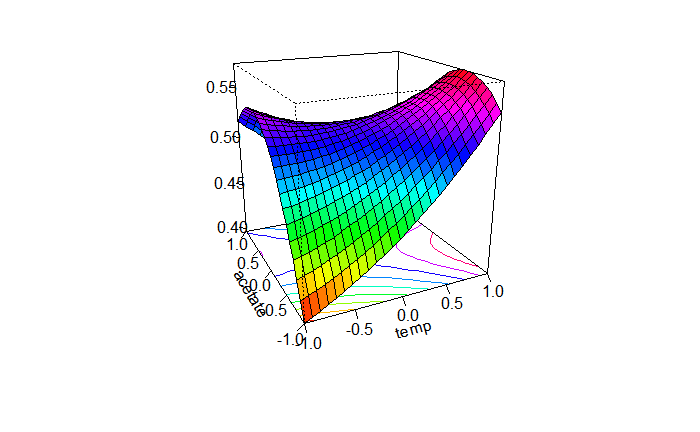

```r
persp(rsmModel, ~ temp + acetate, col = rainbow(50), contours = "colors")
```

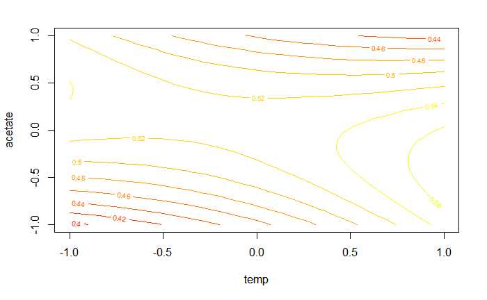

```r
contour(rsmModel, ~ temp + acetate, col = rainbow(50), contours = "colors")
```

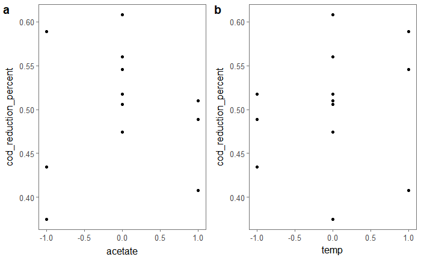

```r
#Look at slices against each factor
plot_acetate <- ggplot(cycle_5_rsm_training, aes(acetate, cod_reduction_percent)) + geom_point() + theme_few()
plot_temp <- ggplot(cycle_5_rsm_training, aes(temp, cod_reduction_percent)) + geom_point() + theme_few()
plot_grid(plot_acetate, plot_temp, align='h', labels=c('a', 'b'))
```

Did time periods differ for each cycle? Maybe we should normalize by cod reduction per day, then rerun analysis.

```r
library(lubridate)
cycleTimes <- read_csv("cycleTimes.csv")
cycleTimes$start <- mdy(cycleTimes$start)
cycleTimes$end <- mdy(cycleTimes$end)
cycleTimes$duration_days <- cycleTimes$end-cycleTimes$start
```

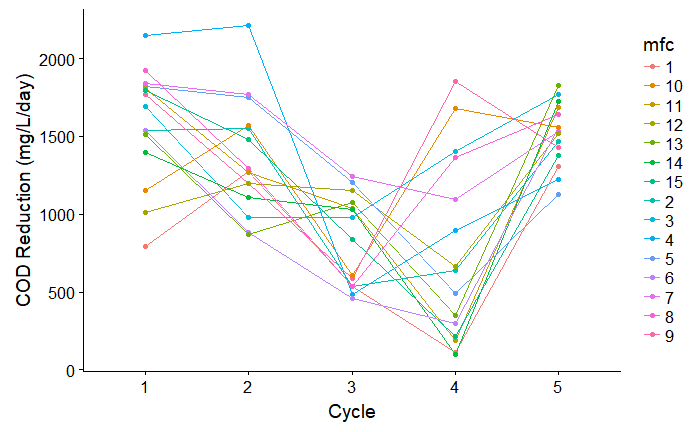

```r
cod <- as_tibble(cod)
cod$cycle_duration <- unlist(cycleTimes[match(cod$cycle,cycleTimes$cycle),"duration_days"])
packages(tibbletime)
cod$delta_cod_mg_L_day <- cod$delta_cod_mg_L/cod$cycle_duration
#plot
ggplot(data=cod, aes(x = cycle,delta_cod_mg_L_day, group=mfc)) +
  geom_line(aes(color=mfc))+
  geom_point(aes(color=mfc))+
  xlab("Cycle")+
  ylab("COD Reduction (mg/L/day)")
```

```r
# run analysis
write_csv(cod,"cod_output_from_R_time_normalized.csv")
cod$cycle <- as.numeric(cod$cycle)
model <- lm(delta_cod_mg_L_day~mfc*cycle,data = cod)
anova(model)
```

```
Analysis of Variance Table

Response: delta_cod_mg_L_day
          Df   Sum Sq Mean Sq F value Pr(>F)
mfc       14  2397484  171249  0.5335 0.8997
cycle      1   816547  816547  2.5439 0.1177
mfc:cycle 14  1998032  142717  0.4446 0.9497
Residuals 45 14444190  320982
```

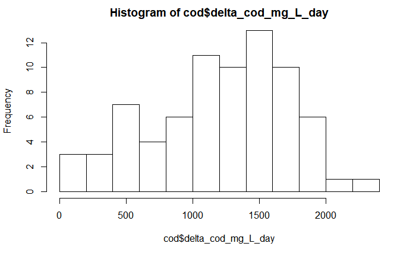

```r
# try data transformation
# check for normality
hist(cod$delta_cod_mg_L_day)
```

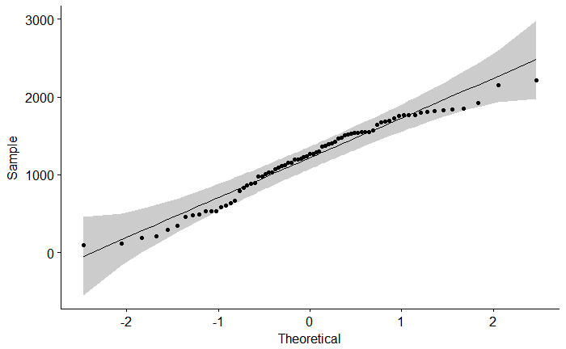

```r
packages(ggpubr)
ggqqplot(cod$delta_cod_mg_L_day)
```

```r
shapiro.test(cod$delta_cod_mg_L_day) # if p<.05, reject null hypothesis that data is normal, there is evidence data not normal
```

```
    Shapiro-Wilk normality test

data:  cod$delta_cod_mg_L_day
W = 0.96508, p-value = 0.0365
```

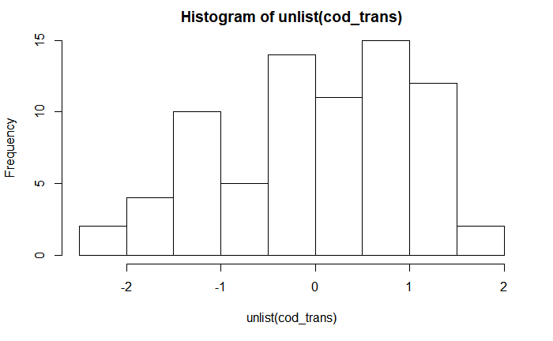

```r
#preprocess
packages(caret)
packages(e1071)
trans = preProcess(data.frame(cod[,"delta_cod_mg_L_day"]), c("BoxCox", "center", "scale"))
cod_trans = data.frame(trans = predict(trans, data.frame(cod[,"delta_cod_mg_L_day"])))
# Visualize again
hist(unlist(cod_trans))
```

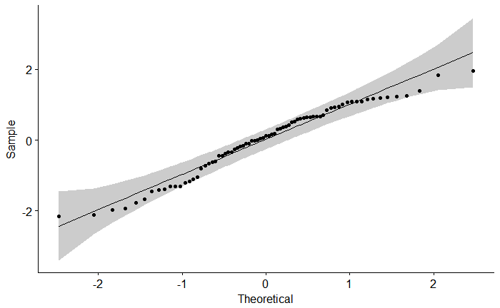

```r
ggqqplot(unlist(cod_trans))
```

```r
shapiro.test(unlist(cod_trans))
```

```
    Shapiro-Wilk normality test

data:  unlist(cod_trans)
W = 0.96508, p-value = 0.0365
```

```r
# Attach transformed variables to data set
colnames(cod_trans) <- "trans_delta_cod_mg_L_day"
cod <- cbind(cod,cod_trans)
write_csv(cod,"cod_output_from_R.csv")
# analyze
trans_model <- lm(trans_delta_cod_mg_L_day~mfc*cycle,data = cod)
anova(trans_model)
```

```
Analysis of Variance Table

Response: trans_delta_cod_mg_L_day
          Df Sum Sq Mean Sq F value Pr(>F)
mfc       14  9.026 0.64470  0.5335 0.8997
cycle      1  3.074 3.07406  2.5439 0.1177
mfc:cycle 14  7.522 0.53729  0.4446 0.9497
Residuals 45 54.378 1.20840
```

Does Cycle 5 COD reduction (delta_cod_mg_L_day) fit to our response surface?

```r
#attach relevant data
cycle_5_rsm <- cbind(rsm_cols,cod$delta_cod_mg_L_day[cod$cycle %in% 5])
colnames(cycle_5_rsm)[5] <- "delta_cod_mg_L_day"
#Build model
cycle_5_rsm_training <- cycle_5_rsm[-c(14:15),] #take off validation points
rsmModel <- rsm(delta_cod_mg_L_day ~ SO(temp, acetate), data = cycle_5_rsm_training)
summary(rsmModel)
```

```
Call:
rsm(formula = delta_cod_mg_L_day ~ SO(temp, acetate), data = cycle_5_rsm_training)

              Estimate Std. Error t value  Pr(>|t|)
(Intercept)  1585.8202    74.4583 21.2981 1.267e-07 ***
temp           51.1905    73.2068  0.6993   0.50695
acetate         4.7619    73.2068  0.0650   0.94996
temp:acetate -176.7857    89.6597 -1.9717   0.08926 .
temp^2         52.0936   107.9004  0.4828   0.64398
acetate^2    -215.7635   107.9004 -1.9997   0.08566 .
---
Signif. codes:  0 ‘***’ 0.001 ‘**’ 0.01 ‘*’ 0.05 ‘.’ 0.1 ‘ ’ 1

Multiple R-squared:  0.5475,    Adjusted R-squared:  0.2243
F-statistic: 1.694 on 5 and 7 DF,  p-value: 0.2537

Analysis of Variance Table

Response: delta_cod_mg_L_day
                   Df Sum Sq Mean Sq F value  Pr(>F)
FO(temp, acetate)   2  15859    7929  0.2466 0.78797
TWI(temp, acetate)  1 125013  125013  3.8878 0.08926
PQ(temp, acetate)   2 131505   65752  2.0448 0.19982
Residuals           7 225088   32155
Lack of fit         3 128190   42730  1.7639 0.29269
Pure error          4  96898   24224

Stationary point of response surface:
      temp    acetate
-0.2788015  0.1252529

Eigenanalysis:
$values
[1]   78.63359 -242.30354

$vectors
              [,1]      [,2]
temp    -0.9577603 0.2875679
acetate  0.2875679 0.9577603
```

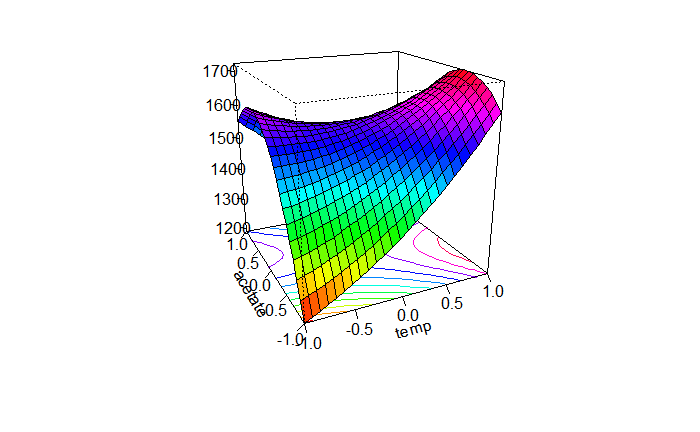

```r
persp(rsmModel, ~ temp + acetate, col = rainbow(50), contours = "colors")
```

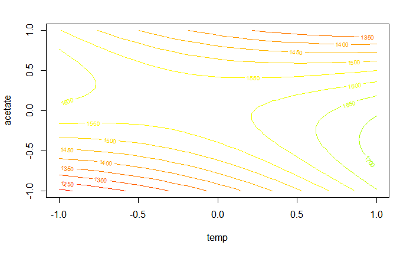

```r
contour(rsmModel, ~ temp + acetate, col = rainbow(50), contours = "colors")
```

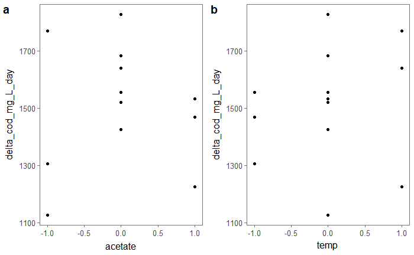

```r
#Look at slices against each factor
plot_acetate <- ggplot(cycle_5_rsm_training, aes(acetate, delta_cod_mg_L_day)) + geom_point() + theme_few()
plot_temp <- ggplot(cycle_5_rsm_training, aes(temp, delta_cod_mg_L_day)) + geom_point() + theme_few()
plot_grid(plot_acetate, plot_temp, align='h', labels=c('a', 'b'))
```

It looks like the cycle 5 delta_cod_mg_L_day doesn’t fit to the response surface either. So the higher voltages seen in response to temperature and acetate must be due to either enhanced efficiency of bioelectrochemical activity by the biofilm or pure noise.

Now let’s pull in all the voltage data over all times. Then we can integrate to find coulombic efficiency.

```r
voltage_data <- rbind(read_csv('voltage_1.csv'),read_csv('voltage_2.csv'))
voltage_data <- voltage_data[,-18] #lop off channel 16 which wasn't used
voltage_data$Date <- mdy(voltage_data$Date)
voltage_data$dateTime <- with(voltage_data, ymd(voltage_data$Date) + hms(voltage_data$Time)) #https://stackoverflow.com/questions/11609252/r-tick-data-merging-date-and-time-into-a-single-object
voltage_data <- select(voltage_data,dateTime,everything()) #move dateTime to front
voltage_data$dateTime <- as.POSIXct(voltage_data$dateTime)
voltage_data <- voltage_data[order(voltage_data$dateTime),] #make sure in order
# double check this worked - do any times not match with their date times?
voltage_data[format(voltage_data$dateTime, "%H:%M:%S") != format(voltage_data$Time, "%H:%M:%S"),] # everything matches up
```

| dateTime | Date | Time | 1 | 2 | 3 | 4 | 5 | 6 | 7 | 8 | 9 | 10 | 11 | 12 | 13 | 14 | 15 |
| --- | --- | --- | --- | --- | --- | --- | --- | --- | --- | --- | --- | --- | --- | --- | --- | --- | --- |

```r
# remove bad data from voltage collector crashing
voltage_data <- voltage_data[year(voltage_data$dateTime) < 2018,]
#We missed some data when the picologger crashed. Let's interpolate around 9/20/2017.
voltage_data[voltage_data$Date < "2017-09-21" & voltage_data$Date > "2017-09-18",]
```

| dateTime | Date | Time | 1 | 2 | 3 | 4 | 5 | 6 | 7 | 8 | 9 | 10 | 11 | 12 | 13 | 14 | 15 |
| --- | --- | --- | --- | --- | --- | --- | --- | --- | --- | --- | --- | --- | --- | --- | --- | --- | --- |
| 2017-09-19 00:12:22 | 2017-09-19 | 00:12:22 | 0.062 | 0.065 | 0.050 | 0.074 | 0.079 | 0.057 | 0.073 | 0.066 | 0.059 | 0.051 | 0.047 | 0.062 | 0.065 | 0.041 | 0.066 |
| 2017-09-19 00:32:22 | 2017-09-19 | 00:32:22 | 0.061 | 0.065 | 0.051 | 0.074 | 0.079 | 0.057 | 0.073 | 0.066 | 0.059 | 0.051 | 0.047 | 0.062 | 0.065 | 0.041 | 0.066 |
| 2017-09-19 00:52:22 | 2017-09-19 | 00:52:22 | 0.062 | 0.065 | 0.050 | 0.074 | 0.079 | 0.057 | 0.073 | 0.066 | 0.059 | 0.051 | 0.047 | 0.062 | 0.065 | 0.041 | 0.066 |
| 2017-09-19 01:12:22 | 2017-09-19 | 01:12:22 | 0.061 | 0.065 | 0.050 | 0.074 | 0.079 | 0.057 | 0.073 | 0.066 | 0.059 | 0.051 | 0.047 | 0.062 | 0.065 | 0.041 | 0.066 |
| 2017-09-19 01:32:22 | 2017-09-19 | 01:32:22 | 0.061 | 0.065 | 0.050 | 0.075 | 0.079 | 0.057 | 0.073 | 0.066 | 0.059 | 0.051 | 0.047 | 0.062 | 0.065 | 0.041 | 0.066 |
| 2017-09-19 01:52:22 | 2017-09-19 | 01:52:22 | 0.061 | 0.065 | 0.050 | 0.075 | 0.079 | 0.057 | 0.073 | 0.066 | 0.059 | 0.051 | 0.047 | 0.062 | 0.065 | 0.041 | 0.066 |
| 2017-09-19 02:12:22 | 2017-09-19 | 02:12:22 | 0.061 | 0.065 | 0.050 | 0.075 | 0.079 | 0.057 | 0.073 | 0.065 | 0.059 | 0.051 | 0.047 | 0.062 | 0.065 | 0.041 | 0.066 |
| 2017-09-19 02:32:22 | 2017-09-19 | 02:32:22 | 0.061 | 0.065 | 0.050 | 0.075 | 0.079 | 0.057 | 0.073 | 0.065 | 0.059 | 0.051 | 0.047 | 0.062 | 0.065 | 0.041 | 0.066 |
| 2017-09-19 02:52:22 | 2017-09-19 | 02:52:22 | 0.061 | 0.065 | 0.050 | 0.075 | 0.079 | 0.057 | 0.073 | 0.065 | 0.059 | 0.050 | 0.047 | 0.062 | 0.065 | 0.041 | 0.066 |
| 2017-09-19 03:12:22 | 2017-09-19 | 03:12:22 | 0.061 | 0.065 | 0.050 | 0.075 | 0.079 | 0.057 | 0.073 | 0.065 | 0.058 | 0.050 | 0.047 | 0.062 | 0.065 | 0.040 | 0.066 |

[output cut: 990 more lines]

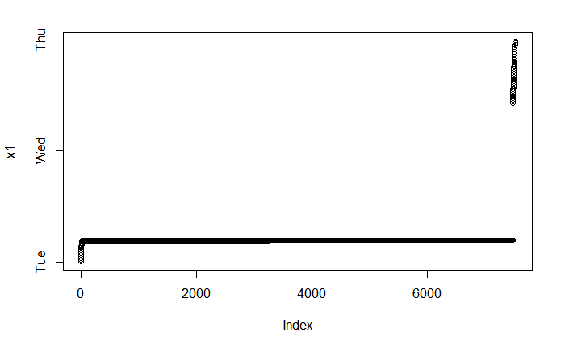

```r
plot(voltage_data[voltage_data$Date > "2017-09-18" & voltage_data$Date < "2017-09-21","dateTime"])
```

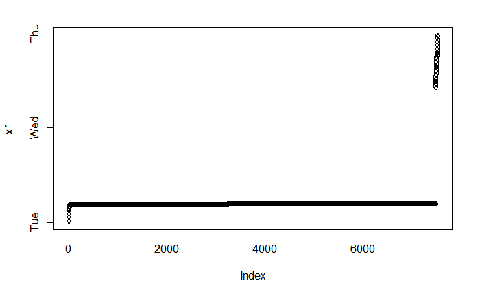

```r
# Looks like 6000 duplicate rows when it crashed. Let's remove those first then interpolate.
plot(voltage_data[voltage_data$Date > "2017-09-18" & voltage_data$Date < "2017-09-21","dateTime"])
```

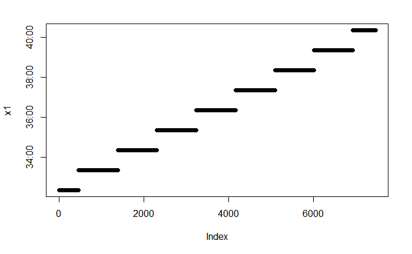

```r
plot(voltage_data[which(duplicated(voltage_data$dateTime)),"dateTime"])
```

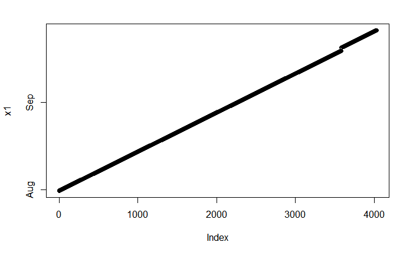

```r
plot(voltage_data[-which(duplicated(voltage_data$dateTime)),"dateTime"])
```

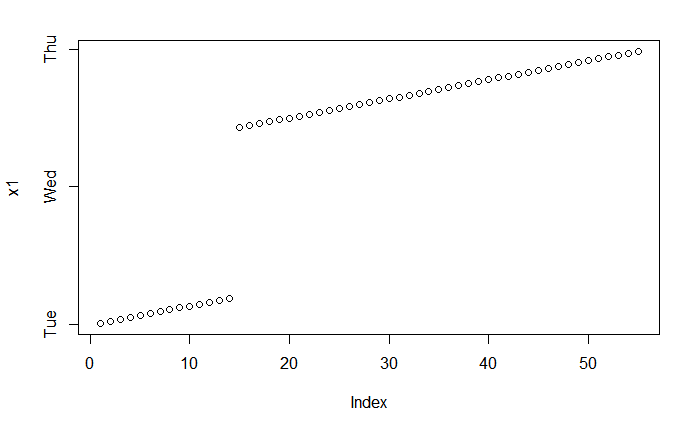

```r
voltage_data <- voltage_data[-which(duplicated(voltage_data$dateTime)),]
# remove 2017-09-19 04:33:22 thru 2017-09-19 04:40:22
voltage_data <- voltage_data[-which(format(voltage_data$Time, "%H:%M:$S") >= "04:33:22" & format(voltage_data$Time, "%H:%M:$S") <= "04:40:22"),]
plot(voltage_data[voltage_data$Date > "2017-09-18" & voltage_data$Date < "2017-09-21","dateTime"])
```

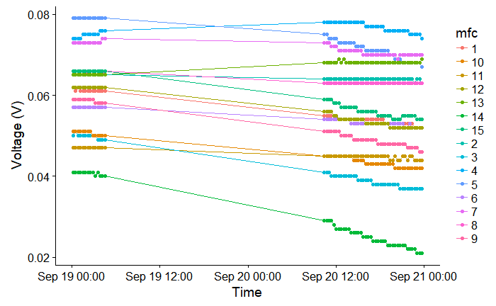

```r
#Now let's interpolate between our missing times.
# between 2017-09-19 04:32:22 and 2017-09-20 10:21:51
test <- voltage_data[voltage_data$Date > "2017-09-18" & voltage_data$Date < "2017-09-21",]
test_melt <- gather(test,"mfc","voltage",4:ncol(voltage_data))
#Visualize
ggplot(data=test_melt, aes(x = dateTime,y = voltage, group=mfc)) +
  geom_line(aes(color=mfc))+
  geom_point(aes(color=mfc))+
  xlab("Time")+
  ylab("Voltage (V)")
```

```r
#interpolate test data set
packages(padr)
test$dateTime <- as.POSIXct(format(test$dateTime, "%Y-%m-%d %H:%M:00")) #strip off seconds so padr doesn't get confused
test$dateTime[15] <- as.POSIXct("2017-09-20 10:32:00")
paddedTime <- test %>% pad(interval="20 min",by = 'dateTime',start_val=as.POSIXct("2017-09-19 04:32:00"),end_val=as.POSIXct("2017-09-20 10:32:00"))
paddedTime <- paddedTime[-1,] #remove first row
paddedTime <- paddedTime[-nrow(paddedTime),]
#put paddedTime back into test data frame
test <- rbind(test,paddedTime)
test <- test[order(test$dateTime),] #it works
#put paddedTime back into voltage_data data frame
# are there any NAs currently in voltage_data?
voltage_data[is.na(voltage_data$Date),] #don't seem to be
```

| dateTime | Date | Time | 1 | 2 | 3 | 4 | 5 | 6 | 7 | 8 | 9 | 10 | 11 | 12 | 13 | 14 | 15 |
| --- | --- | --- | --- | --- | --- | --- | --- | --- | --- | --- | --- | --- | --- | --- | --- | --- | --- |

```r
voltage_data[format(voltage_data$dateTime, "%H:%M:%S") != format(voltage_data$Time, "%H:%M:%S"),] # works fine here
```

| dateTime | Date | Time | 1 | 2 | 3 | 4 | 5 | 6 | 7 | 8 | 9 | 10 | 11 | 12 | 13 | 14 | 15 |
| --- | --- | --- | --- | --- | --- | --- | --- | --- | --- | --- | --- | --- | --- | --- | --- | --- | --- |